# Pertemuan 1

# INPUT DATA

```r
library(forecast)
```

```r
library(graphics)
library(TTR)
library(TSA)
library(rio)
data <- read.csv("C:\\Users\\Na'aila\\Documents\\Semester 5\\MPDW\\PRAK\\ispu_anggota_2.csv")

data$periode <- 1:nrow(data)
head(data)
```

```
##      tanggal            stasiun pm25 pm10 so2 co o3 no2 max critical categori
## 1 2020-12-29 DKI1 (Bunderan HI)   NA   21  23  5 28   6  28       O3     BAIK
## 2 2020-12-30 DKI1 (Bunderan HI)   NA   19  22  4 25   7  30     PM25     BAIK
## 3 2020-12-31 DKI1 (Bunderan HI)   NA   26  25  8 29  10  39     PM25     BAIK
## 4 2021-01-01 DKI1 (Bunderan HI)   53   38  29  6 31  13  53     PM25   SEDANG
## 5 2021-01-02 DKI1 (Bunderan HI)   46   27  27  7 47   7  47       O3     BAIK
## 6 2021-01-03 DKI1 (Bunderan HI)   58   44  25  7 40  13  58     PM25   SEDANG
##   periode
## 1       1
## 2       2
## 3       3
## 4       4
## 5       5
## 6       6
```

# Eksplorasi Data

## Menampilkan data dalam bentuk tabel

```r
View(data)
```

## Menampilkan Struktur data

```r
str(data)
```

```
## 'data.frame':    112 obs. of  12 variables:
##  $ tanggal : chr  "2020-12-29" "2020-12-30" "2020-12-31" "2021-01-01" ...
##  $ stasiun : chr  "DKI1 (Bunderan HI)" "DKI1 (Bunderan HI)" "DKI1 (Bunderan HI)" "DKI1 (Bunderan HI)" ...
##  $ pm25    : num  NA NA NA 53 46 58 48 53 58 47 ...
##  $ pm10    : num  21 19 26 38 27 44 30 38 41 35 ...
##  $ so2     : num  23 22 25 29 27 25 24 24 23 22 ...
##  $ co      : num  5 4 8 6 7 7 4 6 13 6 ...
##  $ o3      : num  28 25 29 31 47 40 32 31 46 39 ...
##  $ no2     : num  6 7 10 13 7 13 7 9 13 10 ...
##  $ max     : num  28 30 39 53 47 58 48 53 58 47 ...
##  $ critical: chr  "O3" "PM25" "PM25" "PM25" ...
##  $ categori: chr  "BAIK" "BAIK" "BAIK" "SEDANG" ...
##  $ periode : int  1 2 3 4 5 6 7 8 9 10 ...
```

## Menampilkan dimensi data

```r
dim(data)
```

```
## [1] 112  12
```

## Mengubah data agar terbaca sebagai data deret waktu dengan fungsi ts()

```r
data.ts <- ts(data$pm10)
data.ts
```

```
## Time Series:
## Start = 1
## End = 112
## Frequency = 1
##   [1] 21 19 26 38 27 44 30 38 41 35 37 47 23 38 29 34 36 42 52 52 40 31 35 43 49
##  [26] 72 33 56 52 20 27 30 27 36 59 30 23 36 29 27 25 24 33 32 26 41 25 33 34 26
##  [51] 39 43 29 30 31 51 50 30 31 29 49 43 37 38 49 51 52 51 57 47 36 45 27 44 37
##  [76] 39 45 55 59 64 60 55 43 38 37 32 25 50 53 54 55 53 43 26 41 25 57 52 33 30
## [101] 38 54 48 45 55 55 51 56 55 65 57 63
```

## Menampilkan ringkasan data

```r
summary(data.ts)
```

```
##    Min. 1st Qu.  Median    Mean 3rd Qu.    Max.
##   19.00   30.00   38.50   40.67   51.00   72.00
```

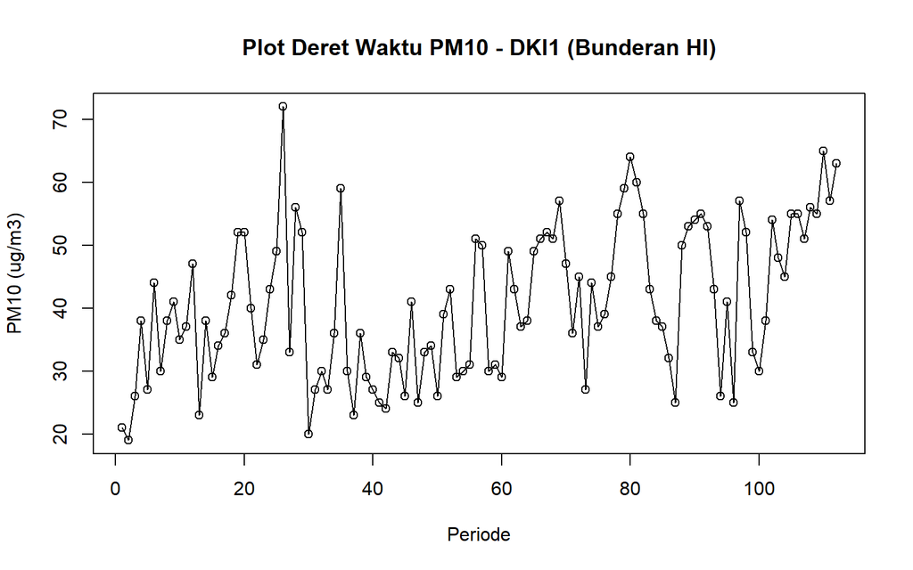

```r
ts.plot(data.ts, xlab = "Periode", ylab = "PM10 (ug/m3)", main = "Plot Deret Waktu PM10 - DKI1 (Bunderan HI)")
points(data.ts)
```

Deret waktu PM10 di DKI1 (Bundaran HI) menunjukkan fluktuasi yang cukup tinggi selama periode pengamatan, dengan nilai berkisar sekitar 19–72 µg/m³. Pada awal periode, nilai PM10 cenderung berada pada tingkat yang lebih rendah, sedangkan pada periode akhir terlihat kecenderungan nilai yang lebih tinggi. Terdapat beberapa lonjakan dan penurunan yang cukup tajam, sementara pola musiman yang jelas belum terlihat secara visual. Oleh karena itu, diperlukan metode pemulusan seperti Single Moving Average untuk mengidentifikasi pola dan memperoleh hasil peramalan yang lebih baik.

# Single Moving Average & Double MOving Average

## Pembagian data (80% data latih dan 20% data uji)

```r
n <- nrow(data)
n_train <- floor(0.8*n)

training <- data[1:n_train, ]
testing <- data[(n_train + 1):n, ]

train.ts <- ts(training$pm10)
test.ts <- ts(testing$pm10)

n_train
```

```
## [1] 89
```

```r
n_test <- nrow(testing)
n_test
```

```
## [1] 23
```

### Eksplorasi Data Latih

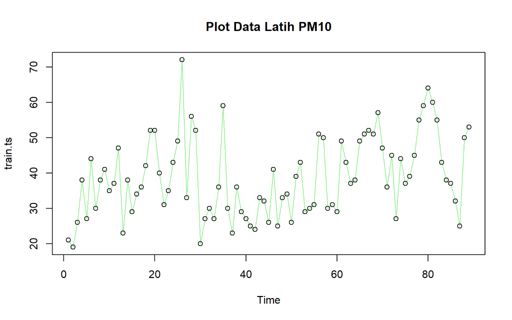

```r
plot(train.ts, col = "lightgreen", main = "Plot Data Latih PM10"); points(train.ts)
```

```r
dev.copy(png, "plot_pm10_train.png"); dev.off()
```

Plot data latih menunjukkan nilai PM10 yang cukup naik turun selama 89 periode. Nilainya berada sekitar 19–72 µg/m³, dengan beberapa kenaikan yang cukup tinggi seperti pada periode 26 dan 35. Pada bagian akhir, nilai PM10 cenderung lebih tinggi dibandingkan beberapa periode sebelumnya, walaupun masih terdapat beberapa penurunan.

### Eksplorasi Data Uji

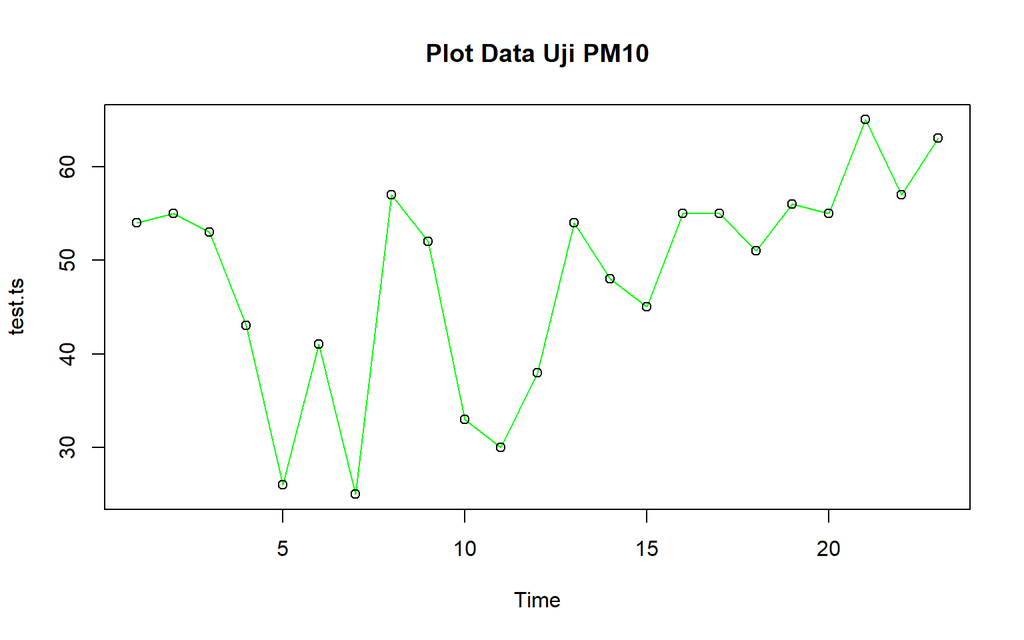

```r
plot(test.ts, col = "green", main = "Plot Data Uji PM10"); points(test.ts)
```

```r
dev.copy(png, "plot_pm10_test.png"); dev.off()
```

Plot data uji menunjukkan nilai PM10 yang juga cukup berfluktuasi. Pada awal data, nilai PM10 berada sekitar 54–55 µg/m³ lalu sempat turun hingga sekitar 25 µg/m³ pada periode 7. Setelah itu, nilainya kembali meningkat dan pada beberapa periode terakhir cenderung berada di atas 50 µg/m³, bahkan mencapai sekitar 65 µg/m³.

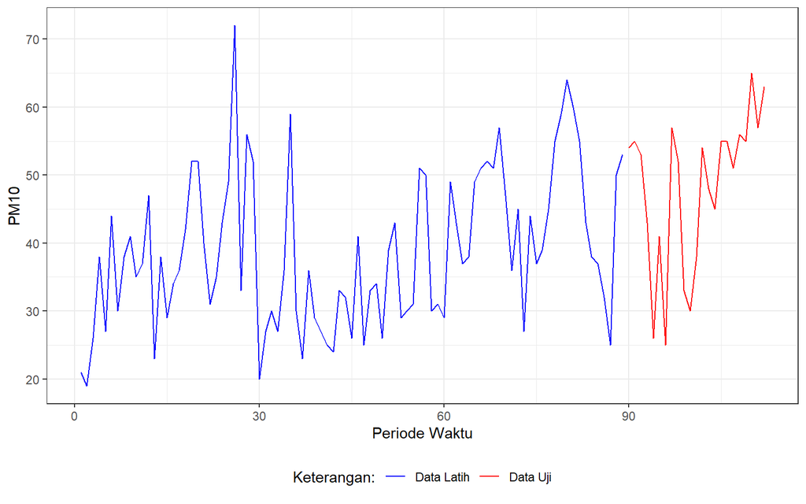

```r
library(ggplot2)
ggplot() +
  geom_line(data = training, aes(x = periode, y = pm10, col = "Data Latih")) +
  geom_line(data = testing,  aes(x = periode, y = pm10, col = "Data Uji")) +
  labs(x = "Periode Waktu", y = "PM10", color = "Legend") +
  scale_colour_manual(name = "Keterangan:", breaks = c("Data Latih", "Data Uji"),
                       values = c("blue", "red")) +
  theme_bw() + theme(legend.position = "bottom")
```

Grafik menunjukkan bahwa data latih (biru) dan data uji (merah) sama-sama mengalami fluktuasi PM10 yang cukup tinggi. Data latih berada sekitar 20–72 µg/m³, sedangkan data uji berada sekitar 25–65 µg/m³. Pada data uji, terlihat bahwa nilai PM10 cenderung meningkat di bagian akhir periode, walaupun masih terdapat beberapa penurunan. Secara umum, pola data uji masih mengikuti kondisi data latih, sehingga data latih dapat digunakan sebagai dasar untuk melakukan peramalan pada data uji.

# Single Moving Average (SMA)

```r
m <- 7
data.sma <- SMA(train.ts,n = m)
data.sma
```

```
## Time Series:
## Start = 1
## End = 89
## Frequency = 1
##  [1]       NA       NA       NA       NA       NA       NA 29.28571 31.71429
##  [9] 34.85714 36.14286 36.00000 38.85714 35.85714 37.00000 35.71429 34.71429
## [17] 34.85714 35.57143 36.28571 40.42857 40.71429 41.00000 41.14286 42.14286
## [25] 43.14286 46.00000 43.28571 45.57143 48.57143 46.42857 44.14286 41.42857
## [33] 35.00000 35.42857 35.85714 32.71429 33.14286 34.42857 34.28571 34.28571
## [41] 32.71429 27.71429 28.14286 29.42857 28.00000 29.71429 29.42857 30.57143
## [49] 32.00000 31.00000 32.00000 34.42857 32.71429 33.42857 33.14286 35.57143
## [57] 39.00000 37.71429 36.00000 36.00000 38.71429 40.42857 38.42857 36.71429
## [65] 39.42857 42.28571 45.57143 45.85714 47.85714 49.28571 49.00000 48.42857
## [73] 45.00000 43.85714 41.85714 39.28571 39.00000 41.71429 43.71429 49.00000
## [81] 51.28571 53.85714 54.42857 53.42857 50.85714 47.00000 41.42857 40.00000
## [89] 39.71429
```

```r
data.ramal <- c(NA, data.sma)
data.ramal
```

```
##  [1]       NA       NA       NA       NA       NA       NA       NA 29.28571
##  [9] 31.71429 34.85714 36.14286 36.00000 38.85714 35.85714 37.00000 35.71429
## [17] 34.71429 34.85714 35.57143 36.28571 40.42857 40.71429 41.00000 41.14286
## [25] 42.14286 43.14286 46.00000 43.28571 45.57143 48.57143 46.42857 44.14286
## [33] 41.42857 35.00000 35.42857 35.85714 32.71429 33.14286 34.42857 34.28571
## [41] 34.28571 32.71429 27.71429 28.14286 29.42857 28.00000 29.71429 29.42857
## [49] 30.57143 32.00000 31.00000 32.00000 34.42857 32.71429 33.42857 33.14286
## [57] 35.57143 39.00000 37.71429 36.00000 36.00000 38.71429 40.42857 38.42857
## [65] 36.71429 39.42857 42.28571 45.57143 45.85714 47.85714 49.28571 49.00000
## [73] 48.42857 45.00000 43.85714 41.85714 39.28571 39.00000 41.71429 43.71429
## [81] 49.00000 51.28571 53.85714 54.42857 53.42857 50.85714 47.00000 41.42857
## [89] 40.00000 39.71429
```

```r
data.ramal <- c(NA, data.sma)
data.ramal
```

```
##  [1]       NA       NA       NA       NA       NA       NA       NA 29.28571
##  [9] 31.71429 34.85714 36.14286 36.00000 38.85714 35.85714 37.00000 35.71429
## [17] 34.71429 34.85714 35.57143 36.28571 40.42857 40.71429 41.00000 41.14286
## [25] 42.14286 43.14286 46.00000 43.28571 45.57143 48.57143 46.42857 44.14286
## [33] 41.42857 35.00000 35.42857 35.85714 32.71429 33.14286 34.42857 34.28571
## [41] 34.28571 32.71429 27.71429 28.14286 29.42857 28.00000 29.71429 29.42857
## [49] 30.57143 32.00000 31.00000 32.00000 34.42857 32.71429 33.42857 33.14286
## [57] 35.57143 39.00000 37.71429 36.00000 36.00000 38.71429 40.42857 38.42857
## [65] 36.71429 39.42857 42.28571 45.57143 45.85714 47.85714 49.28571 49.00000
## [73] 48.42857 45.00000 43.85714 41.85714 39.28571 39.00000 41.71429 43.71429
## [81] 49.00000 51.28571 53.85714 54.42857 53.42857 50.85714 47.00000 41.42857
## [89] 40.00000 39.71429
```

```r
h_test <- n_test
data.gab <- cbind(aktual=c(data.ts),
               pemulusan=c(data.sma,rep(NA, h_test)),
               ramalan=c(data.ramal, rep(data.ramal[length(data.ramal)], h_test-1)))
tail(data.gab, h_test +2)
```

```
##        aktual pemulusan  ramalan
##  [88,]     50  40.00000 41.42857
##  [89,]     53  39.71429 40.00000
##  [90,]     54        NA 39.71429
##  [91,]     55        NA 39.71429
##  [92,]     53        NA 39.71429
##  [93,]     43        NA 39.71429
##  [94,]     26        NA 39.71429
##  [95,]     41        NA 39.71429
##  [96,]     25        NA 39.71429
##  [97,]     57        NA 39.71429
##  [98,]     52        NA 39.71429
##  [99,]     33        NA 39.71429
## [100,]     30        NA 39.71429
## [101,]     38        NA 39.71429
## [102,]     54        NA 39.71429
## [103,]     48        NA 39.71429
## [104,]     45        NA 39.71429
## [105,]     55        NA 39.71429
## [106,]     55        NA 39.71429
## [107,]     51        NA 39.71429
## [108,]     56        NA 39.71429
## [109,]     55        NA 39.71429
## [110,]     65        NA 39.71429
## [111,]     57        NA 39.71429
## [112,]     63        NA 39.71429
```

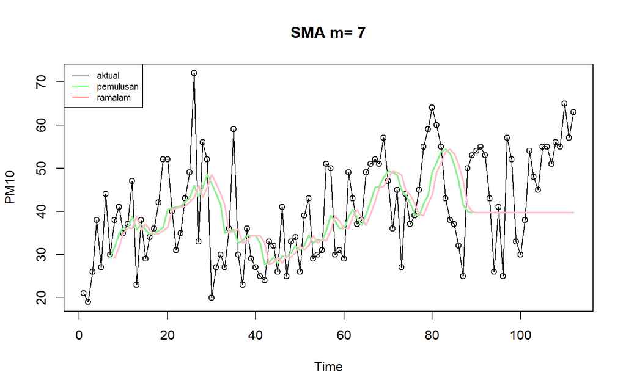

```r
ts.plot(data.ts, xlabt = "Periode", ylab = "PM10", main = paste("SMA m=", m))
points(data.ts)
lines(data.gab[,2], col = "lightgreen", lwd=2)
lines(data.gab[,3], col = "pink", lwd =2 )
legend("topleft", c("aktual", "pemulusan", "ramalam"), lty =1, col = c("black", "green", "red"), cex =0.7)
```

```r
dev.copy(png, "plot_sma.png"); dev.off()
```

Pada grafik terlihat bahwa garis pemulusan (hijau) mengikuti pola umum data aktual, tetapi tidak mampu mengikuti perubahan yang sangat tajam. Hal ini merupakan karakteristik SMA: karena menggunakan rata-rata 7 periode sebelumnya, perubahan ekstrem pada data aktual akan dihaluskan dan respons model menjadi lebih lambat. Garis ramalan (merah) kemudian berada relatif konstan di sekitar nilai 40 PM10 setelah periode tertentu. Ini menunjukkan bahwa ramalan SMA cenderung mengikuti nilai rata-rata beberapa pengamatan terakhir, sehingga kurang responsif terhadap fluktuasi mendadak.

## Menghitung nilai keakuratan data latih

```r
error_train.sma <- train.ts - data.ramal[1:length(train.ts)]
SSE_train.sma  <- sum(error_train.sma[(m+1):length(train.ts)]^2)
MSE_train.sma  <- mean(error_train.sma[(m+1):length(train.ts)]^2)
RMSE_train.sma <- sqrt(MSE_train.sma)
MAPE_train.sma <- mean(abs(error_train.sma[(m+1):length(train.ts)] /
                             train.ts[(m+1):length(train.ts)]) * 100)

akurasi_train.sma <- matrix(c(SSE_train.sma, MSE_train.sma, RMSE_train.sma, MAPE_train.sma))
row.names(akurasi_train.sma) <- c("SSE", "MSE", "RMSE", "MAPE")
colnames(akurasi_train.sma) <- paste("SMA m =", m)
akurasi_train.sma
```

```
##        SMA m = 7
## SSE  10652.73469
## MSE    129.91140
## RMSE    11.39787
## MAPE    25.31535
```

Untuk akurasi data latih, metode SMA dengan periode 7 menghasilkan nilai SSE sebesar 10.652,73, MSE sebesar 129,91, RMSE sebesar 11,40, dan MAPE sebesar 25,32%. Nilai tersebut menunjukkan bahwa pada data latih, rata-rata kesalahan persentase peramalan adalah sebesar 25,32%, sedangkan penyimpangan hasil peramalan terhadap nilai aktual berdasarkan RMSE adalah sekitar 11,40 satuan PM10.

## Menghitung nilai keakuratan data uji

```r
idx_test <- (length(train.ts) + 1):n
error_test.sma <- test.ts - data.gab[idx_test, 3]
SSE_test.sma  <- sum(error_test.sma^2)
MSE_test.sma  <- mean(error_test.sma^2)
RMSE_test.sma <- sqrt(MSE_test.sma)
MAPE_test.sma <- mean(abs(error_test.sma / test.ts) * 100)

akurasi_test.sma <- matrix(c(SSE_test.sma, MSE_test.sma, RMSE_test.sma, MAPE_test.sma))
row.names(akurasi_test.sma) <- c("SSE", "MSE", "RMSE", "MAPE")
colnames(akurasi_test.sma) <- paste("SMA m =", m)
akurasi_test.sma
```

```
##       SMA m = 7
## SSE  4498.02041
## MSE   195.56610
## RMSE   13.98450
## MAPE   26.48371
```

Untuk akurasi data uji, metode SMA dengan periode 7 menghasilkan nilai SSE sebesar 4.498,02, MSE sebesar 195,57, RMSE sebesar 13,98, dan MAPE sebesar 26,48%. Nilai MAPE sebesar 26,48% menunjukkan bahwa rata-rata kesalahan peramalan pada data uji sekitar 26,48%. Dibandingkan dengan data latih, nilai MAPE dan RMSE pada data uji lebih tinggi, sehingga dapat dikatakan bahwa kemampuan model dalam melakukan peramalan pada data baru sedikit menurun.

# Double Moving Average (DMA)

```r
dma <- SMA(data.sma, n = m)
at <- 2*data.sma -dma
bt <- 2/(m-1) *(data.sma - dma)
data.dma <- at + bt
data.ramald <- c(NA, data.dma)

t <- 1:h_test
f <- c()
for (i in t) {
  f[i] <- at[length(at)] + bt[length(bt)] * i
}

data.gab2 <- cbind(
  aktual     = c(data.ts),
  pemulusan1 = c(data.sma, rep(NA, h_test)),
  pemulusan2 = c(dma, rep(NA, h_test)),
  at         = c(at, rep(NA, h_test)),
  bt         = c(bt, rep(NA, h_test)),
  ramalan    = c(data.ramald, f[-1])
)
tail(data.gab2, h_test + 2)
```

```
##        aktual pemulusan1 pemulusan2       at        bt     ramalan
##  [88,]     50   40.00000   48.71429 31.28571 -2.904762  29.5646259
##  [89,]     53   39.71429   46.69388 32.73469 -2.326531  28.3809524
##  [90,]     54         NA         NA       NA        NA  30.4081633
##  [91,]     55         NA         NA       NA        NA  28.0816327
##  [92,]     53         NA         NA       NA        NA  25.7551020
##  [93,]     43         NA         NA       NA        NA  23.4285714
##  [94,]     26         NA         NA       NA        NA  21.1020408
##  [95,]     41         NA         NA       NA        NA  18.7755102
##  [96,]     25         NA         NA       NA        NA  16.4489796
##  [97,]     57         NA         NA       NA        NA  14.1224490
##  [98,]     52         NA         NA       NA        NA  11.7959184
##  [99,]     33         NA         NA       NA        NA   9.4693878
## [100,]     30         NA         NA       NA        NA   7.1428571
## [101,]     38         NA         NA       NA        NA   4.8163265
## [102,]     54         NA         NA       NA        NA   2.4897959
## [103,]     48         NA         NA       NA        NA   0.1632653
## [104,]     45         NA         NA       NA        NA  -2.1632653
## [105,]     55         NA         NA       NA        NA  -4.4897959
## [106,]     55         NA         NA       NA        NA  -6.8163265
## [107,]     51         NA         NA       NA        NA  -9.1428571
## [108,]     56         NA         NA       NA        NA -11.4693878
## [109,]     55         NA         NA       NA        NA -13.7959184
## [110,]     65         NA         NA       NA        NA -16.1224490
## [111,]     57         NA         NA       NA        NA -18.4489796
## [112,]     63         NA         NA       NA        NA -20.7755102
```

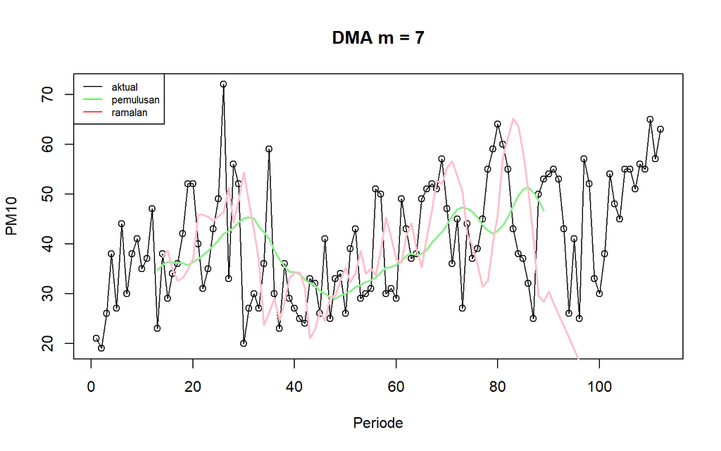

```r
ts.plot(data.ts, xlab = "Periode", ylab = "PM10", main = paste("DMA m =", m))
points(data.ts)
lines(data.gab2[, 3], col = "lightgreen", lwd = 2)
lines(data.gab2[, 6], col = "pink", lwd = 2)
legend("topleft", c("aktual", "pemulusan", "ramalan"), lty = 1,
       col = c("black", "green", "red"), cex = 0.7)
```

```r
dev.copy(png, "plot_dma.png"); dev.off()
```

Pada grafik DMA m = 7, garis pemulusan mampu mengikuti tren umum data PM10, tetapi kurang responsif terhadap perubahan yang tiba-tiba. Garis ramalan juga terlihat cukup jauh dari data aktual pada beberapa periode, terutama di bagian akhir. Hal ini menunjukkan bahwa DMA m = 7 masih kurang mampu menangkap fluktuasi tajam pada data PM10.

## Menghitung keakuraratan data latih

```r
start_dma <- 2 * m
error_train.dma <- train.ts - data.ramald[1:length(train.ts)]
SSE_train.dma  <- sum(error_train.dma[start_dma:length(train.ts)]^2)
MSE_train.dma  <- mean(error_train.dma[start_dma:length(train.ts)]^2)
RMSE_train.dma <- sqrt(MSE_train.dma)
MAPE_train.dma <- mean(abs(error_train.dma[start_dma:length(train.ts)] /
                             train.ts[start_dma:length(train.ts)]) * 100)

akurasi_train.dma <- matrix(c(SSE_train.dma, MSE_train.dma, RMSE_train.dma, MAPE_train.dma))
row.names(akurasi_train.dma) <- c("SSE", "MSE", "RMSE", "MAPE")
colnames(akurasi_train.dma) <- paste("DMA m =", m)
akurasi_train.dma
```

```
##        DMA m = 7
## SSE  13607.75672
## MSE    179.04943
## RMSE    13.38094
## MAPE    28.94872
```

Berdasarkan hasil perhitungan, metode Double Moving Average (DMA) dengan periode 7 pada data latih menghasilkan nilai SSE sebesar 13.607,76, MSE sebesar 179,04, RMSE sebesar 13,38, dan MAPE sebesar 28,95%. Nilai MAPE sebesar 28,95% menunjukkan bahwa rata-rata kesalahan peramalan terhadap data aktual berada di sekitar 28,95%. Dengan demikian, tingkat akurasi model pada data latih dapat dikategorikan cukup baik, karena nilai kesalahan peramalan masih relatif rendah dibandingkan dengan data uji.

## Menghitung keakuratan data uji

```r
error_test.dma <- test.ts - data.gab2[idx_test, 6]
SSE_test.dma  <- sum(error_test.dma^2)
MSE_test.dma  <- mean(error_test.dma^2)
RMSE_test.dma <- sqrt(MSE_test.dma)
MAPE_test.dma <- mean(abs(error_test.dma / test.ts) * 100)

akurasi_test.dma <- matrix(c(SSE_test.dma, MSE_test.dma, RMSE_test.dma, MAPE_test.dma))
row.names(akurasi_test.dma) <- c("SSE", "MSE", "RMSE", "MAPE")
colnames(akurasi_test.dma) <- paste("DMA m =", m)
akurasi_test.dma
```

```
##        DMA m = 7
## SSE  55349.90212
## MSE   2406.51748
## RMSE    49.05627
## MAPE    85.13966
```

Pada data uji, metode Double Moving Average (DMA) dengan periode 7 menghasilkan nilai SSE sebesar 55.349,90, MSE sebesar 2.406,52, RMSE sebesar 49,06, dan MAPE sebesar 85,14%. Nilai MAPE sebesar 85,14% menunjukkan bahwa rata-rata kesalahan peramalan mencapai sekitar 85,14%. Hal ini menunjukkan bahwa tingkat akurasi model pada data uji tergolong rendah, karena nilai kesalahan peramalan cukup besar. Peningkatan nilai RMSE dan MAPE dibandingkan data latih juga menunjukkan bahwa model DMA periode 7 kurang mampu melakukan peramalan dengan baik pada data yang belum pernah digunakan dalam proses pembentukan model.

# Single Exponential Smoothing (SES)

```r
ses.opt <- HoltWinters(train.ts, gamma = FALSE, beta = FALSE, alpha = NULL )
ses.opt
```

```
## Holt-Winters exponential smoothing without trend and without seasonal component.
##
## Call:
## HoltWinters(x = train.ts, alpha = NULL, beta = FALSE, gamma = FALSE)
##
## Smoothing parameters:
##  alpha: 0.3322744
##  beta : FALSE
##  gamma: FALSE
##
## Coefficients:
##       [,1]
## a 44.27412
```

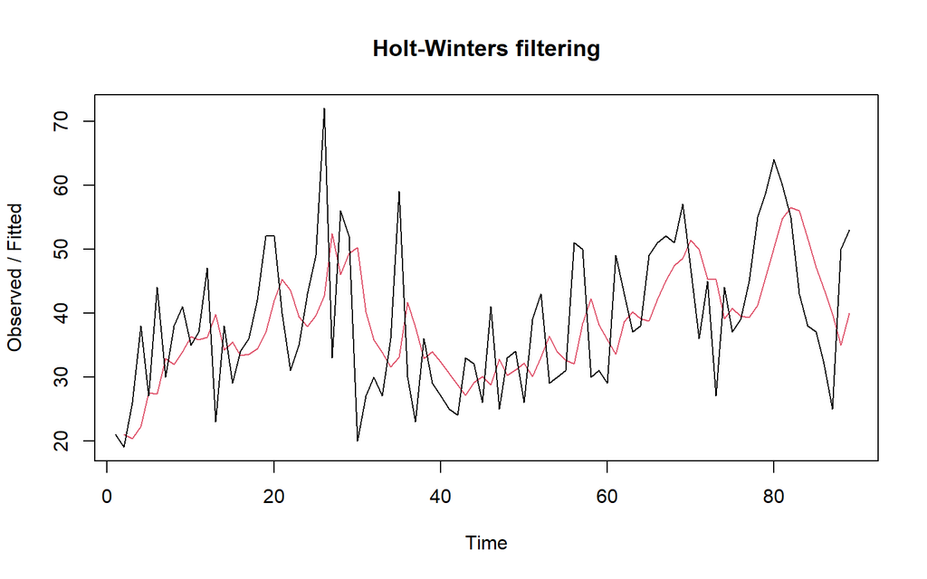

```r
plot(ses.opt); dev.copy(png, "plot_ses.png"); dev.off()
```

Berdasarkan grafik Holt-Winters filtering, garis hitam menunjukkan data aktual, sedangkan garis merah menunjukkan hasil pemulusan (fitted value). Terlihat bahwa garis merah mengikuti pola umum data aktual, terutama dalam menangkap tren kenaikan dan penurunan data, tetapi tidak sepenuhnya mengikuti perubahan yang terjadi secara cepat. Pada beberapa periode dengan perubahan yang cukup tajam, seperti lonjakan atau penurunan nilai aktual, garis hasil pemulusan terlihat lebih halus dan cenderung terlambat mengikuti perubahan tersebut. Hal ini menunjukkan bahwa metode Holt-Winters mampu menangkap pola umum dan kecenderungan data, tetapi kurang responsif terhadap fluktuasi yang terjadi secara tiba-tiba. Secara keseluruhan, hasil filtering menunjukkan bahwa model dapat memberikan gambaran tren data dengan lebih stabil dibandingkan data aktual yang memiliki fluktuasi cukup tinggi.

```r
ramalan.ses <- forecast(ses.opt, h = n_test)
ramalan.ses
```

```
##     Point Forecast    Lo 80    Hi 80     Lo 95    Hi 95
##  90       44.27412 30.69922 57.84903 23.513098 65.03515
##  91       44.27412 29.96946 58.57879 22.397024 66.15122
##  92       44.27412 29.27516 59.27309 21.335186 67.21306
##  93       44.27412 28.61161 59.93664 20.320373 68.22787
##  94       44.27412 27.97505 60.57320 19.346839 69.20140
##  95       44.27412 27.36243 61.18581 18.409923 70.13832
##  96       44.27412 26.77124 61.77700 17.505780 71.04246
##  97       44.27412 26.19938 62.34886 16.631194 71.91705
##  98       44.27412 25.64507 62.90318 15.783443 72.76480
##  99       44.27412 25.10678 63.44147 14.960198 73.58805
## 100       44.27412 24.58320 63.96505 14.159450 74.38879
## 101       44.27412 24.07318 64.47506 13.379449 75.16879
## 102       44.27412 23.57573 64.97251 12.618662 75.92958
## 103       44.27412 23.08996 65.45829 11.875735 76.67251
## 104       44.27412 22.61507 65.93317 11.149466 77.39878
## 105       44.27412 22.15038 66.39786 10.438783 78.10946
## 106       44.27412 21.69525 66.85299  9.742723 78.80552
## 107       44.27412 21.24912 67.29912  9.060420 79.48782
## 108       44.27412 20.81147 67.73678  8.391087 80.15716
## 109       44.27412 20.38183 68.16641  7.734014 80.81423
## 110       44.27412 19.95978 68.58846  7.088549 81.45969
## 111       44.27412 19.54494 69.00331  6.454098 82.09415
## 112       44.27412 19.13694 69.41131  5.830117 82.71813
```

Hasil peramalan SES dengan alpha 0,332 menunjukkan nilai ramalan konstan sebesar 44,27 untuk periode mendatang. Interval prediksi semakin lebar pada periode yang lebih jauh, sehingga menunjukkan bahwa ketidakpastian ramalan meningkat seiring bertambahnya periode peramalan.

## Menghitung keakuratan data latih

```r
SSE.ses <- ses.opt$SSE
MSE.ses <- SSE.ses / length(train.ts)
RMSE.ses <- sqrt(MSE.ses)
sisaan.ses <- ramalan.ses$residuals
MAPE.ses <- mean(abs(sisaan.ses[2:length(train.ts)]/train.ts[2:length(train.ts)])*100)

akurasi_train.ses <- matrix(c(SSE.ses, MSE.ses, MAPE.ses))
row.names(akurasi_train.ses) <- c("SES", "MSE", "MAPE")
colnames(akurasi_train.ses) <- paste("SES alpha=", round(ses.opt$alpha, 3))
akurasi_train.ses
```

```
##      SES alpha= 0.332
## SES        9817.34375
## MSE         110.30723
## MAPE         23.42279
```

## Menghitung keakuratan data uji

```r
e.ses <- as.numeric(ramalan.ses$mean) - as.numeric(testing$pm10)
SSE_test.ses <- sum(e.ses^2)
MSE_test.ses <- mean(e.ses^2)
RMSE_test.ses <- sqrt(MSE_test.ses)
MAPE_test.ses <- mean(abs(e.ses / testing$pm10) * 100)

akurasi_test.ses <- matrix(c(SSE_test.ses, MSE_test.ses, RMSE_test.ses, MAPE_test.ses))
row.names(akurasi_test.ses) <- c("SSE", "MSE", "RMSE", "MAPE")
colnames(akurasi_test.ses) <- paste("SES alpha =", round (ses.opt$alpha, 3))
akurasi_test.ses
```

```
##      SES alpha = 0.332
## SSE         3174.45216
## MSE          138.01966
## RMSE          11.74818
## MAPE          23.98692
```

Pada data uji, metode Single Exponential Smoothing (SES) dengan alpha 0,332 menghasilkan nilai SSE sebesar 3.174,45, MSE sebesar 138,02, RMSE sebesar 11,75, dan MAPE sebesar 23,99%. Nilai MAPE sebesar 23,99% menunjukkan bahwa rata-rata kesalahan peramalan pada data uji sekitar 23,99%. Nilai tersebut hanya sedikit lebih tinggi dibandingkan MAPE data latih sebesar 23,42%, sehingga dapat dikatakan bahwa kemampuan model dalam melakukan peramalan pada data baru masih cukup baik dan relatif stabil.

# Double Exponential Smoothing (DES)

```r
des.opt <- HoltWinters(train.ts, gamma = FALSE )
des.opt
```

```
## Holt-Winters exponential smoothing with trend and without seasonal component.
##
## Call:
## HoltWinters(x = train.ts, gamma = FALSE)
##
## Smoothing parameters:
##  alpha: 0.4771319
##  beta : 0.03371245
##  gamma: FALSE
##
## Coefficients:
##          [,1]
## a 46.05952861
## b  0.09668476
```

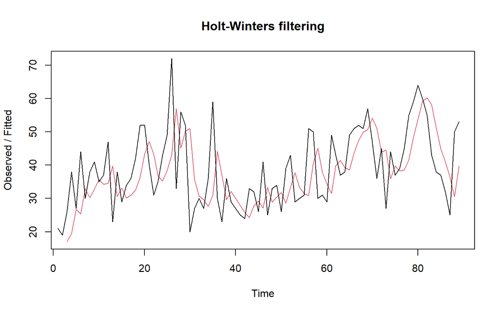

```r
plot(des.opt); dev.copy(png, "plot_des.png"); dev.off()
```

Berdasarkan grafik Double Exponential Smoothing (DES), garis hasil pemulusan mengikuti pola umum data aktual, terutama dalam menangkap tren kenaikan dan penurunan data. Namun, pada beberapa periode dengan perubahan yang tajam, hasil pemulusan masih terlihat lebih halus dibandingkan data aktual. Hal ini menunjukkan bahwa metode DES mampu menangkap tren data dengan cukup baik, tetapi kurang responsif terhadap fluktuasi yang terjadi secara tiba-tiba.

```r
ramalan.des <- forecast(des.opt, h = n_test)
ramalan.des
```

```
##     Point Forecast     Lo 80    Hi 80      Lo 95     Hi 95
##  90       46.15621 32.066122 60.24630  24.607278  67.70515
##  91       46.25290 30.542205 61.96359  22.225466  70.28033
##  92       46.34958 29.077566 63.62160  19.934313  72.76485
##  93       46.44627 27.654688 65.23785  17.707027  75.18551
##  94       46.54295 26.261649 66.82426  15.525375  77.56053
##  95       46.63964 24.889953 68.38932  13.376365  79.90291
##  96       46.73632 23.533333 69.93931  11.250413  82.22223
##  97       46.83301 22.187039 71.47897   9.140252  84.52576
##  98       46.92969 20.847386 73.01200   7.040248  86.81914
##  99       47.02638 19.511468 74.54128   4.945955  89.10680
## 100       47.12306 18.176955 76.06917   2.853812  91.39231
## 101       47.21975 16.841958 77.59753   0.760928  93.67856
## 102       47.31643 15.504927 79.12793  -1.335066  95.96793
## 103       47.41312 14.164580 80.66165  -3.436131  98.26236
## 104       47.50980 12.819849 82.19975  -5.543901 100.56350
## 105       47.60648 11.469837 83.74313  -7.659748 102.87272
## 106       47.70317 10.113788 85.29255  -9.784829 105.19117
## 107       47.79985  8.751058 86.84865 -11.920126 107.51983
## 108       47.89654  7.381103 88.41197 -14.066473 109.85955
## 109       47.99322  6.003457 89.98299 -16.224583 112.21103
## 110       48.08991  4.617719 91.56210 -18.395068 114.57488
## 111       48.18659  3.223549 93.14964 -20.578449 116.95164
## 112       48.28328  1.820652 94.74590 -22.775177 119.34173
```

Berdasarkan hasil peramalan menggunakan metode Double Exponential Smoothing, diperoleh nilai point forecast untuk 23 periode data uji. Hasil peramalan menunjukkan adanya kecenderungan peningkatan nilai, yang terlihat dari nilai ramalan sebesar 46,15621 pada periode ke-90 dan meningkat secara bertahap pada periode-periode berikutnya. Selain itu, hasil peramalan dilengkapi dengan interval prediksi 80% dan 95%. Rentang interval prediksi semakin melebar pada periode yang lebih jauh, yang menunjukkan bahwa tingkat ketidakpastian hasil peramalan meningkat seiring bertambahnya periode yang diramalkan.

## Menghitung keakuratan data latih

```r
SSE.des <- des.opt$SSE
MSE.des <- SSE.des / length(train.ts)
RMSE.des <- sqrt(MSE.des)
sisaan.des <- ramalan.des$residuals
MAPE.des <- mean(abs(sisaan.des[3:length(train.ts)]/
                       train.ts[3:length(train.ts)]) * 100)

akurasi_train.des <- matrix(c(SSE.des, MSE.des, RMSE.des, MAPE.des))
row.names(akurasi_train.des) <- c("SSE", "MSE", "RMSE", "MAPE")
colnames(akurasi_train.des) <- paste0("DES alpha=", round(des.opt$alpha,3),
                                       " beta=", round(des.opt$beta,3))
akurasi_train.des
```

```
##      DES alpha=0.477 beta=0.034
## SSE                 10590.99786
## MSE                   118.99998
## RMSE                   10.90871
## MAPE                   23.84843
```

Berdasarkan hasil perhitungan pada data latih, metode Double Exponential Smoothing (DES) dengan nilai alpha (α) sebesar 0,477 dan beta (β) sebesar 0,034 menghasilkan nilai SSE sebesar 10.590,99786, MSE sebesar 118,99998, RMSE sebesar 10,90871, dan MAPE sebesar 23,84843%. Nilai MAPE tersebut menunjukkan bahwa rata-rata persentase kesalahan hasil peramalan terhadap data aktual pada data latih adalah sebesar 23,85%. Dengan demikian, model DES mampu memberikan hasil peramalan dengan tingkat kesalahan yang masih tergolong cukup baik untuk digunakan dalam proses peramalan.

## Menghitung keakuratan data uji

```r
e.des <- as.numeric(ramalan.des$mean) - as.numeric(testing$pm10)
SSE_test.des  <- sum(e.des^2)
MSE_test.des  <- mean(e.des^2)
RMSE_test.des <- sqrt(MSE_test.des)
MAPE_test.des <- mean(abs(e.des / testing$pm10) * 100)

akurasi_test.des <- matrix(c(SSE_test.des, MSE_test.des, RMSE_test.des, MAPE_test.des))
row.names(akurasi_test.des) <- c("SSE", "MSE", "RMSE", "MAPE")
colnames(akurasi_test.des) <- paste0("DES alpha=", round(des.opt$alpha,3),
                                      " beta=", round(des.opt$beta,3))
akurasi_test.des
```

```
##      DES alpha=0.477 beta=0.034
## SSE                  2688.87821
## MSE                   116.90775
## RMSE                   10.81239
## MAPE                   22.88451
```

Berdasarkan hasil pengujian menggunakan data uji, metode Double Exponential Smoothing (DES) dengan nilai alpha (α) sebesar 0,477 dan beta (β) sebesar 0,034 menghasilkan nilai SSE sebesar 2.688,87821, MSE sebesar 116,90775, RMSE sebesar 10,81239, dan MAPE sebesar 22,88451%. Nilai MAPE menunjukkan bahwa rata-rata persentase kesalahan peramalan terhadap data aktual pada data uji adalah sebesar 22,88%. Hasil tersebut menunjukkan bahwa model DES mampu memberikan hasil peramalan yang cukup baik pada data yang belum digunakan dalam proses pembentukan model.

# Kesimpulan

```r
tabel_akurasi <- data.frame(
  Metode = c("SMA", "DMA", "SES", "DES"),
  SSE_Latih  = c(SSE_train.sma, SSE_train.dma, SSE.ses, SSE.des),
  MSE_Latih  = c(MSE_train.sma, MSE_train.dma, MSE.ses, MSE.des),
  RMSE_Latih = c(RMSE_train.sma, RMSE_train.dma, RMSE.ses, RMSE.des),
  MAPE_Latih = c(MAPE_train.sma, MAPE_train.dma, MAPE.ses, MAPE.des),
  SSE_Uji  = c(SSE_test.sma, SSE_test.dma, SSE_test.ses, SSE_test.des),
  MSE_Uji  = c(MSE_test.sma, MSE_test.dma, MSE_test.ses, MSE_test.des),
  RMSE_Uji = c(RMSE_test.sma, RMSE_test.dma, RMSE_test.ses, RMSE_test.des),
  MAPE_Uji = c(MAPE_test.sma, MAPE_test.dma, MAPE_test.ses, MAPE_test.des)
)
print(tabel_akurasi, digits = 4)
```

```
##   Metode SSE_Latih MSE_Latih RMSE_Latih MAPE_Latih SSE_Uji MSE_Uji RMSE_Uji
## 1    SMA     10653     129.9      11.40      25.32    4498   195.6    13.98
## 2    DMA     13608     179.0      13.38      28.95   55350  2406.5    49.06
## 3    SES      9817     110.3      10.50      23.42    3174   138.0    11.75
## 4    DES     10591     119.0      10.91      23.85    2689   116.9    10.81
##   MAPE_Uji
## 1    26.48
## 2    85.14
## 3    23.99
## 4    22.88
```

Berdasarkan tabel perbandingan hasil pemulusan menggunakan metode SMA, DMA, SES, dan DES, dapat ditarik kesimpulan bahwa metode DES (Double Exponential Smoothing) merupakan metode terbaik untuk data uji, karena menghasilkan nilai kesalahan yang paling rendah dibandingkan metode lainnya.

Pada data latih, metode SES memiliki performa terbaik dengan nilai MSE sebesar 110,3 dan RMSE sebesar 10,50, sedangkan DES menghasilkan MSE sebesar 119,0 dan RMSE sebesar 10,91. Namun, pada data uji, metode DES memberikan hasil terbaik dengan SSE sebesar 2.689, MSE sebesar 116,9, RMSE sebesar 10,81, dan MAPE sebesar 22,88%. Nilai tersebut merupakan yang paling rendah dibandingkan SMA, DMA, dan SES. Sebagai perbandingan, SES menghasilkan MAPE 23,99%, SMA 26,48%, dan DMA 85,14%.

Dengan demikian, DES dipilih sebagai metode pemulusan terbaik karena memiliki tingkat kesalahan paling kecil pada data uji. Hal ini menunjukkan bahwa DES mampu memberikan hasil peramalan yang lebih akurat dan lebih baik dalam memprediksi data yang belum digunakan dalam proses pembentukan model. Selain itu, penggunaan DES sesuai untuk data yang memiliki kecenderungan atau tren, karena metode ini mempertimbangkan komponen level dan tren dalam melakukan peramalan.